# SVM, Random Forests, and beyond

Pablo Barbera

August 9, 2018

### Support Vector Machines

Continuing with our previous example, we’ll now try other classifiers. First up is SVMs – the code below illustrates a common trade-off between performance and interpretability of the model.

```r
library(quanteda)
tweets <- read.csv("~/data/UK-tweets.csv", stringsAsFactors=F)
tweets$engaging <- ifelse(tweets$communication=="engaging", 1, 0)
tweets <- tweets[!is.na(tweets$engaging),]
# clean text and create DFM
tweets$text <- gsub('@[0-9_A-Za-z]+', '@', tweets$text)
twcorpus <- corpus(tweets$text)
twdfm <- dfm(twcorpus, remove=stopwords("english"), remove_url=TRUE,
             ngrams=1:2, verbose=TRUE)
```

```
## Creating a dfm from a corpus input...
```

```
##    ... lowercasing
```

```
##    ... found 4,566 documents, 48,657 features
```

```
##    ... removed 169 features
##    ... created a 4,566 x 48,488 sparse dfm
##    ... complete.
## Elapsed time: 2.49 seconds.
```

```r
twdfm <- dfm_trim(twdfm, min_docfreq = 5, verbose=TRUE)
```

```
## Removing features occurring:
##   - in fewer than 5 documents: 45,755
##   Total features removed: 45,755 (94.4%).
```

```r
# training and test sets
set.seed(123)
training <- sample(1:nrow(tweets), floor(.80 * nrow(tweets)))
test <- (1:nrow(tweets))[1:nrow(tweets) %in% training == FALSE]
```

First, let’s run SVM by choosing manually the cost parameter (regularization term).

```r
library(e1071)
fit <- svm(x=twdfm[training,], y=factor(tweets$engaging[training]),
           kernel="linear", cost=10, probability=TRUE)

preds <- predict(fit, twdfm[test,])

## function to compute accuracy
accuracy <- function(ypred, y){
    tab <- table(ypred, y)
    return(sum(diag(tab))/sum(tab))
}
# function to compute precision
precision <- function(ypred, y){
    tab <- table(ypred, y)
    return((tab[2,2])/(tab[2,1]+tab[2,2]))
}
# function to compute recall
recall <- function(ypred, y){
    tab <- table(ypred, y)
    return(tab[2,2]/(tab[1,2]+tab[2,2]))
}

# confusion matrix
table(preds, tweets$engaging[test])
```

```
##
## preds   0   1
##     0 113  92
##     1  80 629
```

```r
# performance metrics
accuracy(preds, tweets$engaging[test])
```

```
## [1] 0.8118162
```

```r
precision(preds, tweets$engaging[test])
```

```
## [1] 0.887165
```

```r
recall(preds, tweets$engaging[test])
```

```
## [1] 0.8723994
```

Unlike regularized regression, here looking at the estimated coefficients is not as informative because they only tell us what support vectors were estimated in the model. But we can have a sense of what observations are more “important” or “separate” better the data by extracting the support vectors in the data matrix and then their corresponding coefficients (times the training labels):

```r
df <- data.frame(
  vector = tweets$text[training][fit$index],
  coef = fit$coefs,
  stringsAsFactors = F
)

df <- df[order(df$coef),]
head(df[,c("coef", "vector")], n=10)
```

```
##     coef
## 761  -10
## 767  -10
## 775  -10
## 790  -10
## 809  -10
## 814  -10
## 871  -10
## 885  -10
## 907  -10
## 985  -10
##                                                                                             vector
## 761                                          Well done Chevron B34 Paolo Barillla wins Monaco F3 @
## 767                                                                                Viva Rod Petrie
## 775                                                        #EP2014 cands SWEngland @ @ @ @ @ @ @ @
## 790                                                    The one-world selfie http://t.co/vcgqA0RrDu
## 809 Rotten Relations in TurkishFootball which protects MatchFixers http://t.co/yN2TrOC5aM …@ @ @ @
## 814                    A modern jazzy reversion of Mien Kampf @ #twat http://t.co/wRRKomnUB6 via @
## 871                                                                        @ Old Etonian isn't he?
## 885                                               http://t.co/IrhS1H6kzY @ outclassing Ed Milliand
## 907                                                                        @ elected with 159,815.
## 985              Mandy discussing the manifesto document in Wolverhampton @ http://t.co/8DT0LOEyKM
```

```r
df <- df[order(df$coef, decreasing=TRUE),]
head(df[,c("coef", "vector")], n=10)
```

```
##     coef
## 214   10
## 437   10
## 532   10
## 544   10
## 545   10
## 548   10
## 581   10
## 626   10
## 685   10
## 713   10
##                                                                            vector
## 214                                                    @ #opportunists #transient
## 437                                              Why Pray? http://t.co/F2C5ZZCJ6v
## 532                                                                       @ #sobs
## 544                                                                @ #ohyesyouare
## 545                                                                @ tragi-comedy
## 548                                                               @ starts at 9am
## 581                                             @ https://t.co/0lMtYKTfVz germany
## 626 MT '@: I've supported Vote #TUSC on May 22nd on @ // @ http://t.co/LnvjxTm4o4
## 685     GREEN NEWS Peterborough UK is out! http://t.co/tLn6M2uTi8 Stories via @ @
## 713                                                              @ congratulation
```

Note that this will only work with linear kernels.

There’s a version of svm with cross-validation already built-in. We’ll now use to find the best cost parameter:

```r
fit <- tune(svm, train.x=twdfm[training,],
            train.y=factor(tweets$engaging[training]),
            kernel="linear",
            ranges=list(cost=c(0.001, 0.01, 0.1, 1, 5, 10, 100)))
summary(fit)
```

```
##
## Parameter tuning of 'svm':
##
## - sampling method: 10-fold cross validation
##
## - best parameters:
##  cost
##   0.1
##
## - best performance: 0.1114395
##
## - Detailed performance results:
##    cost     error dispersion
## 1 1e-03 0.2231679 0.01707819
## 2 1e-02 0.1883928 0.01187115
## 3 1e-01 0.1114395 0.01761187
## 4 1e+00 0.1388278 0.01747049
## 5 5e+00 0.1667557 0.02373938
## 6 1e+01 0.1703166 0.02220133
## 7 1e+02 0.1768860 0.02423627
```

```r
# best model
bestmodel <- fit$best.model
summary(bestmodel)
```

```
##
## Call:
## best.tune(method = svm, train.x = twdfm[training, ], train.y = factor(tweets$engaging[training]),
##     ranges = list(cost = c(0.001, 0.01, 0.1, 1, 5, 10, 100)),
##     kernel = "linear")
##
##
## Parameters:
##    SVM-Type:  C-classification
##  SVM-Kernel:  linear
##        cost:  0.1
##       gamma:  0.0003658983
##
## Number of Support Vectors:  1523
##
##  ( 881 642 )
##
##
## Number of Classes:  2
##
## Levels:
##  0 1
```

```r
# evaluating performance
preds <- predict(bestmodel, twdfm[test,])
# confusion matrix
table(preds, tweets$engaging[test])
```

```
##
## preds   0   1
##     0 120  42
##     1  73 679
```

```r
# performance metrics
accuracy(preds, tweets$engaging[test])
```

```
## [1] 0.8741794
```

```r
precision(preds, tweets$engaging[test])
```

```
## [1] 0.9029255
```

```r
recall(preds, tweets$engaging[test])
```

```
## [1] 0.9417476
```

```r
df <- data.frame(
  vector = tweets$text[training][bestmodel$index],
  coef = bestmodel$coefs,
  stringsAsFactors = F
)

df <- df[order(df$coef),]
head(df[,c("coef", "vector")], n=10)
```

```
##     coef
## 882 -0.1
## 883 -0.1
## 884 -0.1
## 885 -0.1
## 887 -0.1
## 888 -0.1
## 889 -0.1
## 891 -0.1
## 892 -0.1
## 893 -0.1
##                                                                                                                                vector
## 882                                                          .@ Sally Ibbotson @ comes in second after Labour. http://t.co/MM0KdqPl7A
## 883                              @ is Britain's Berlusconi – someone foreigners look at and say, "How can you vote for this buffoon?"
## 884      “@: Revealed - the #fossilfuel lobbies behind attacks on #renewables - News - The Ecologist http://t.co/dhVXjtWn95 #climate”
## 885                                                                    Unusual polling stations - in pictures  http://t.co/sGmewcCHZd
## 887 While UKIP miss or oppose key votes, @ are working hard to stand up for UK citizens http://t.co/jxwJAF71a5 http://t.co/RHkFhUsG7n
## 888                                            @ spotted among good friends at @ event in Manchester #EU2014 @ http://t.co/AAI63wqLzE
## 889                                                                                         Congratulations to @ on being re-elected!
## 891                                                                        Forest carbon loss 'underestimated' http://t.co/fXjglnu849
## 892                                                                  "seedbombing" one of the more innovative suggestions at #leithnp
## 893                                                                           @ @ Well done to everyone in #Winchester, great result!
```

```r
df <- df[order(df$coef, decreasing=TRUE),]
head(df[,c("coef", "vector")], n=10)
```

```
##    coef
## 1   0.1
## 4   0.1
## 7   0.1
## 13  0.1
## 21  0.1
## 24  0.1
## 29  0.1
## 33  0.1
## 34  0.1
## 38  0.1
##                                                                                                                        vector
## 1                      @ to be fair I think people have been listening to your leader rather than labour this last day or two
## 4  Thanks to @ &amp; @ for covering our https://t.co/GcPbvFVvnY report on BBC ‘Click’. Listen again at http://t.co/iB4Wx9ZuyQ
## 7                                                                          @ @ Is this truly the best use of his time? WTF...
## 13                                                                  @ UKIP: for people incapable of eating without assistance
## 21                                                      Congratulations to @  and @  elected Yorkshire &amp;Humber MEP Labour
## 24                                                       Greens to launch LGBTIQ European manifesto @  http://t.co/XzqauVWLIk
## 29                                                                                                                   Look @ @
## 33      @ @ in metropolitan areas, the wealthy (a lot of foreign oligarchs and billionaires) have priced out ordinary Britons
## 34                                             Out + about with #Peterborough's MEP @ #cllrdarrenfower http://t.co/VN7g94AcJw
## 38                                               @ he is Lenny not Kenny and the person who said that remark has been removed
```

### Random forests

Turning to random forests, we’ll need to dramatically reduce the size of our matrix to make sure it doesn’t take hours to run; so we’ll just pick features that are not frequent but also not too rare. We’ll see that random forests tend to perform quite well, but at the cost of higher computational cost and even less interpretability (we can only learn of “feature importance” – the extent to which a variable tends to separate classes more frequently than others).

```r
library(randomForest)
set.seed(777)

X <- as.matrix(dfm_trim(twdfm, min_docfreq = 50,
                        max_docfreq=0.80*nrow(twdfm), verbose=TRUE))
```

```
## Removing features occurring:
```

```
##   - in fewer than 50 documents: 2,609
```

```
##   - in more than 3652.8 documents: 1
```

```
##   Total features removed: 2,610 (95.5%).
```

```r
dim(X)
```

```
## [1] 4566  123
```

```r
rf <- randomForest(x=X[training,],
                   y=factor(tweets$engaging[training]),
                   xtest=X[test,],
                   ytest=factor(tweets$engaging[test]),
                   importance=TRUE,
                   mtry=20,
                   ntree=100
                   )
rf
```

```
##
## Call:
##  randomForest(x = X[training, ], y = factor(tweets$engaging[training]),      xtest = X[test, ], ytest = factor(tweets$engaging[test]),      ntree = 100, mtry = 20, importance = TRUE)
##                Type of random forest: classification
##                      Number of trees: 100
## No. of variables tried at each split: 20
##
##         OOB estimate of  error rate: 18.07%
## Confusion matrix:
##     0    1 class.error
## 0 408  407  0.49938650
## 1 253 2584  0.08917871
##                 Test set error rate: 20.13%
## Confusion matrix:
##    0   1 class.error
## 0 91 102   0.5284974
## 1 82 639   0.1137309
```

```r
importance(rf)
```

```
##                           0            1 MeanDecreaseAccuracy
## thank           0.404034591  3.331322524          4.086123157
## !               0.951601140  5.060794919          4.766557273
## look            0.441457091 -0.460575003         -0.127346111
## @_@            34.891786749 15.293939691         36.236265663
## @_thank         4.860124501  4.102580349          5.039955957
## thank_you       4.634467423  4.196317354          5.108207654
## have_a         -3.362470887 -0.078766628         -1.723293352
## .               3.785506224  7.196413239          8.209250429
## :               1.328411888 16.757946462         15.360255748
## '              11.091733535  5.561275037         10.084594671
## go              1.700440524 -1.867451924         -0.611152517
## ?               3.494834241 11.328889484         12.115317330
## @_and           6.582342540  5.906028384          8.688767945
## really          3.089598032 -1.255732909          1.078010715
## "               3.732292699  6.204320330          8.056073428
## done           -1.583779330 -1.048253344         -1.612880288
## ,              -0.181748509  5.829864729          4.489022625
## now             2.989190584  3.640882215          4.980673054
## time           -1.998960499  0.002802874         -0.942076883
## is_a           -1.985114853  1.159323050          0.352833870
## new            -0.005745222  1.366208938          0.996225976
## election       -0.191472351  2.533014200          2.343492680
## campaign        3.971290055  8.774066970          8.257557590
## "_@            -1.858572212  3.057888911          2.169099542
## @_:            -3.849810817  6.675199511          4.740958406
## for_the        -3.603365923  2.350208769         -0.064047167
## ._.             0.021003542  1.833973472          1.786137593
## think          -2.520282913  1.802751596         -0.318773972
## i_think         1.871914999 -0.913632536          0.116101594
## /               0.201732892  2.706647199          2.283671374
## much           -2.475588923  3.494119839          2.271244158
## know           -0.810362944 -1.448363190         -1.477923517
## ._@             0.674330817  1.855324116          2.119906708
## -              -0.996242766  8.023298655          6.055051001
## ,_but           0.954155658 -0.345417073          0.196331166
## @_is            5.842738137  6.830571280          8.637270404
## ._i            -1.011114186  3.500015839          2.411817154
## ukip            0.350906176 -0.996556267         -0.688625396
## &               0.339414734  1.935558297          2.308806119
```

[output cut: 193 more lines]

```
## %                     3.8657799
## to_@                 14.4110898
## us                    3.9937197
## may                   6.3954885
## make                  4.0346282
## say                   2.4059946
## scotland              2.1853072
## @_many                0.9120189
## via                  11.6982583
## via_@                13.6049394
## got                   3.2102596
## take                  3.6316162
## news                  4.7665145
## many_thanks           0.8964799
## thanks_for            0.5753982
```

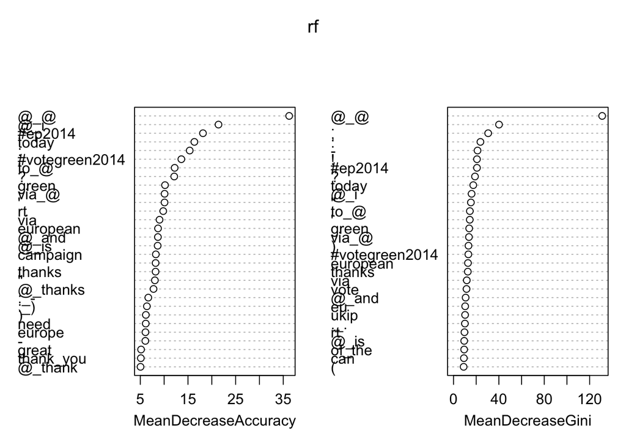

```r
varImpPlot(rf)
```

## Ensemble methods

One interesting way to run supervised learning algorithms is to **combine** the using ensemble methods. The idea is the following: run each method, check how well they perform, and then pick a prediction for the units in the test set that is weighted according to how well each classifier performs. The `SuperLearner` package in R is probably the best library for ensemble methods in ML.

```r
library(SuperLearner)
# X needs to be a data frame
Xtrain <- as.data.frame(as.matrix(dfm_trim(twdfm, min_docfreq = 100,
                        max_docfreq=0.80*nrow(twdfm), verbose=TRUE)))
```

```
## Removing features occurring:
```

```
##   - in fewer than 100 documents: 2,684
```

```
##   - in more than 3652.8 documents: 1
```

```
##   Total features removed: 2,685 (98.2%).
```

```r
features <- names(Xtrain)
names(Xtrain) <- paste0("V", 1:ncol(Xtrain))

set.seed(777)

sl <- SuperLearner(Y = tweets$engaging[training], X = Xtrain[training,],
                  family = binomial(),
                  SL.library = c("SL.mean", "SL.glmnet",
                                "SL.step"),
                  cvControl=list(V=5))
sl
```

```
##
## Call:
## SuperLearner(Y = tweets$engaging[training], X = Xtrain[training, ],
##     family = binomial(), SL.library = c("SL.mean", "SL.glmnet", "SL.step"),
##     cvControl = list(V = 5))
##
##
##                    Risk      Coef
## SL.mean_All   0.1734652 0.0000000
## SL.glmnet_All 0.1401416 0.4493452
## SL.step_All   0.1400493 0.5506548
```

```r
# what other classifiers are available?
listWrappers()
```

```
## All prediction algorithm wrappers in SuperLearner:
```

```
##  [1] "SL.bartMachine"      "SL.bayesglm"         "SL.biglasso"
##  [4] "SL.caret"            "SL.caret.rpart"      "SL.cforest"
##  [7] "SL.dbarts"           "SL.earth"            "SL.extraTrees"
## [10] "SL.gam"              "SL.gbm"              "SL.glm"
## [13] "SL.glm.interaction"  "SL.glmnet"           "SL.ipredbagg"
## [16] "SL.kernelKnn"        "SL.knn"              "SL.ksvm"
## [19] "SL.lda"              "SL.leekasso"         "SL.lm"
## [22] "SL.loess"            "SL.logreg"           "SL.mean"
## [25] "SL.nnet"             "SL.nnls"             "SL.polymars"
## [28] "SL.qda"              "SL.randomForest"     "SL.ranger"
## [31] "SL.ridge"            "SL.rpart"            "SL.rpartPrune"
## [34] "SL.speedglm"         "SL.speedlm"          "SL.step"
## [37] "SL.step.forward"     "SL.step.interaction" "SL.stepAIC"
## [40] "SL.svm"              "SL.template"         "SL.xgboost"
```

```
##
## All screening algorithm wrappers in SuperLearner:
```

```
## [1] "All"
## [1] "screen.corP"           "screen.corRank"        "screen.glmnet"
## [4] "screen.randomForest"   "screen.SIS"            "screen.template"
## [7] "screen.ttest"          "write.screen.template"
```

```r
# measuring peformance
preds <- predict(sl, Xtrain[test,])
head(preds$library.predict)
```

```
##      SL.mean_All SL.glmnet_All SL.step_All
## [1,]   0.7768346     0.9926007   0.9972790
## [2,]   0.7768346     0.5873418   0.5825969
## [3,]   0.7768346     0.9145715   0.9237239
## [4,]   0.7768346     0.6367596   0.6152044
## [5,]   0.7768346     0.7397472   0.7820490
## [6,]   0.7768346     0.8825395   0.8837987
```

```r
preds <- preds$pred > 0.50

# confusion matrix
table(preds, tweets$engaging[test])
```

```
##
## preds     0   1
##   FALSE  46  29
##   TRUE  147 692
```

```r
# performance metrics
accuracy(preds, tweets$engaging[test])
```

```
## [1] 0.8074398
```

```r
precision(preds, tweets$engaging[test])
```

```
## [1] 0.8247914
```

```r
recall(preds, tweets$engaging[test])
```

```
## [1] 0.9597781
```